# The impact of isosmotic conditions on the metabolism and hypoxia tolerance of a reportedly oxyconforming teleost

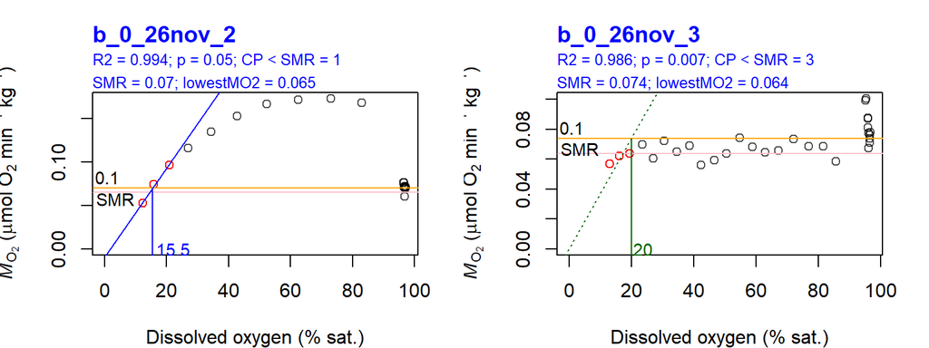

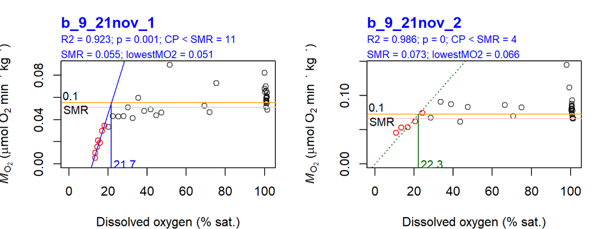

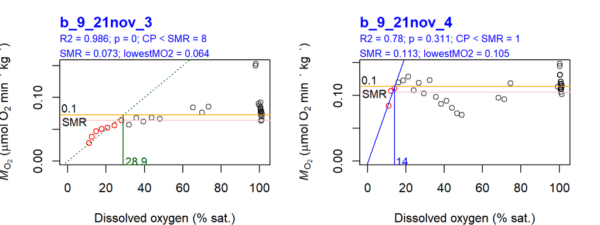

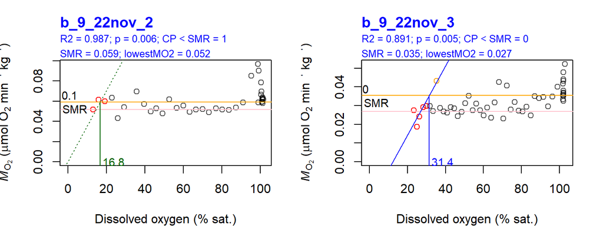

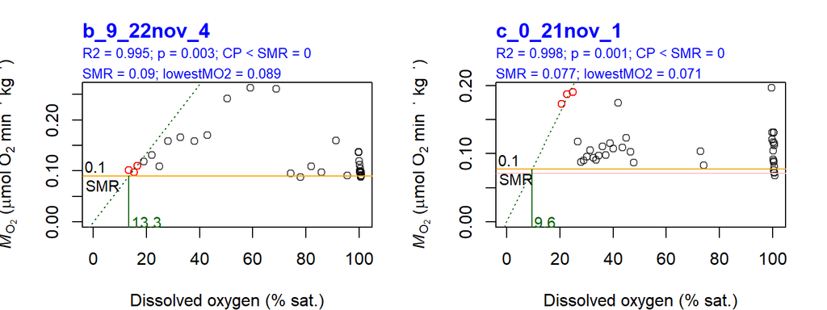

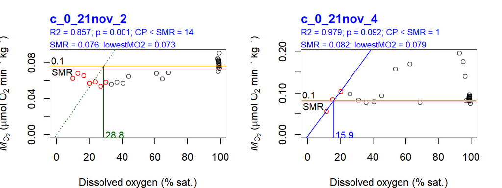

[7 more figures not shown]

### O₂crit numerical rules

We applied a numerical rule to asses if a O<sub>2crit</sub> was observed. Specifically, we filtered for only cases were at the lowest O₂ value three consecutive MO₂ measures full below our SMR and fifth percentile of the MO2 values observed at dissolved O2 levels > 80%. In the model output these are called nb_mo2_conforming points.

```
## [1] "Based on this rule there are 16 fish with possible O₂crits."
```

#### Figure S6

Plotting fish that meet our numerical rule for O<sub>2crit</sub>

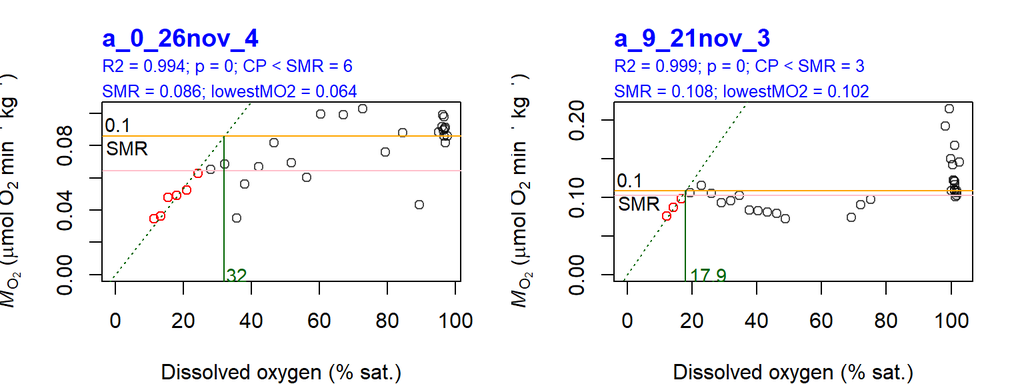

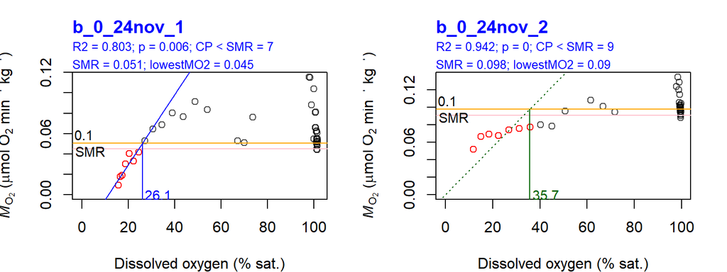

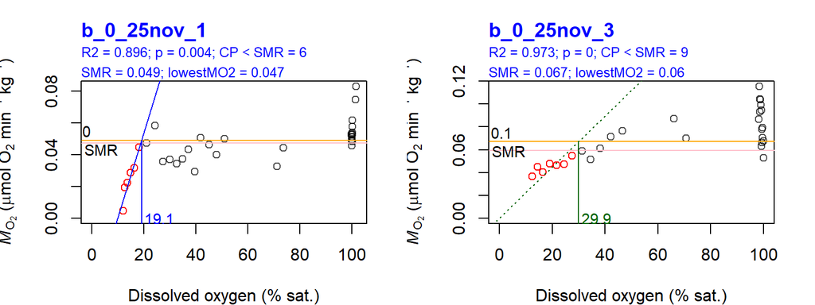

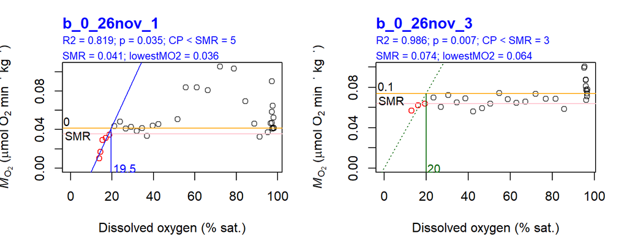

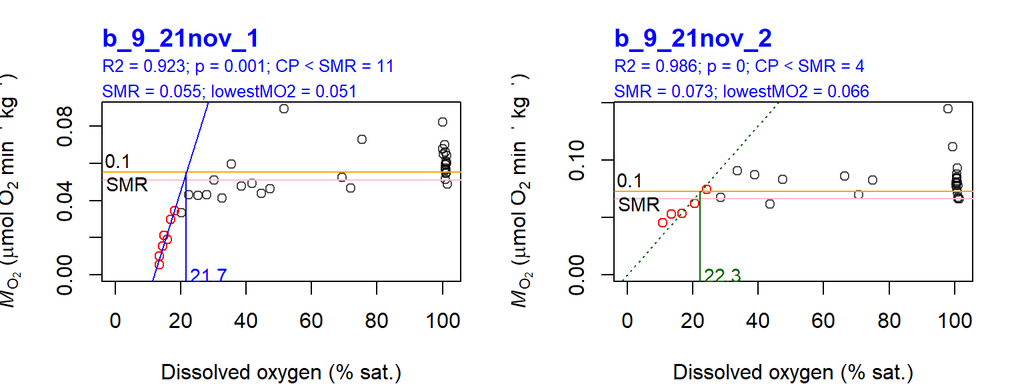

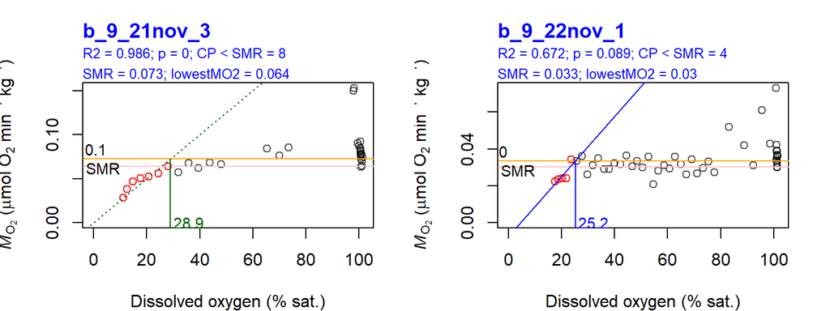

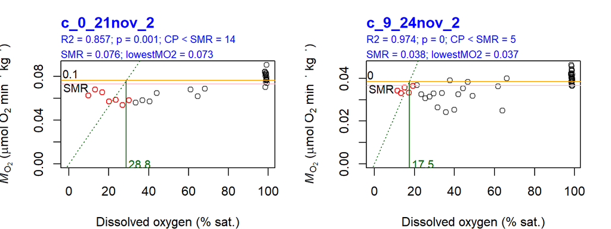

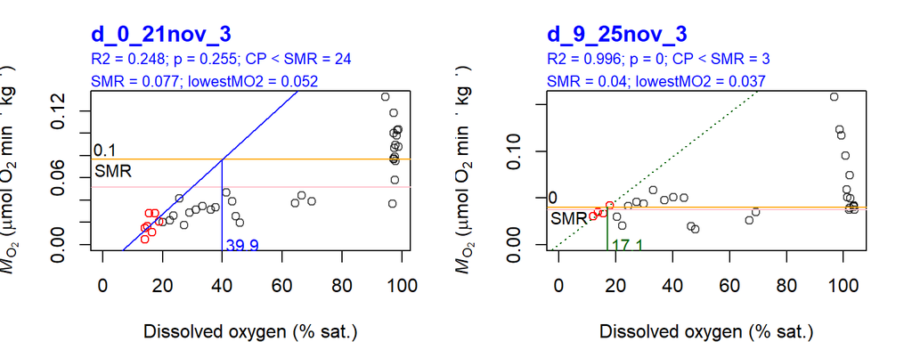

**Figure S6**: Representative examples of fish that were best modelled by a 2nd- or 3rd-order polynomial and meet the numerical inclusion criteria. The horizontal solid orange line shows the standard metabolic rate (SMR), the horizontal solid pink line shows thelowestMO2 (as defined by Claireaux and Chabot (2016)), the solid/dashed blue/green slope line shows the O2 regulation failure regression (based on the rule-based linear regression method of Claireaux and Chabot (2016); where the colour and line type indicate the type of regression fitted, through orgin or not), and the solid vertical blue/green line shows the O2crit estimate (intersection of O2 failure regression and SMR).

How many from each salinity treatment

| salinity_group | n |
| --- | --- |
| 0 | 9 |
| 9 | 7 |

### Visual inspection

We conducted visual inspection of all 58 fish to determine if O<sub>2crits</sub> were present. We have loaded this as a data frame **💿 o2crit_check**

For this visual inspection, we grouped fish into “no”, “maybe” or “yes”, based on the certainty at which we observed a O<sub>2crits</sub>. In the case of yes or maybe, we also estimate dissolved oxygen percentage. All authors did this independently.

#### 📈 Results

Let’s figure out how consistent the categorisation was, and what the majority response was. There were 35 cases with no disagreements (60.34%), 23 cases with one or more disagreements (39.66%).

| cat_disagreement | n | percent |
| --- | --- | --- |
| 0 | 35 | 60.34 |
| 1 | 23 | 39.66 |

#### Figure S7

Here’s a heat map to show decisions for each fish

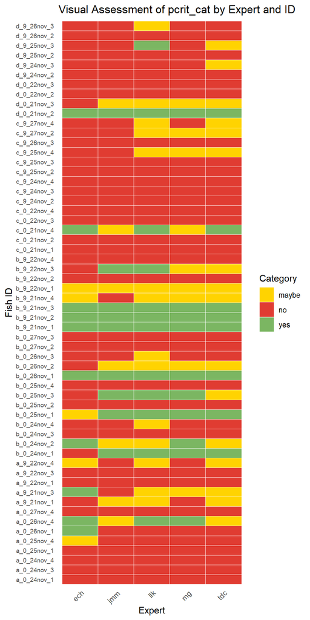

**Figure S7**: Heatmap showing the visual assessment of critical oxygen saturation (O<sub>2crits</sub>) category (“no”, “maybe” or “yes”) for each fish by expert assessor (Elizabeth C. Hoots [ech], Jake M. Martin [jmm], Luis L. Kuchenmülle [llk] Maryane Gradito [mg], Timothy D. Clark [tdc]). Each tile represents one fish-expert pairing, colour-coded by assigned category: **no** (red, #E03C32), **maybe** (yellow, #FFD301), and **yes** (green, #7BB662).

Expert deviation from the majority assessment ranged from 22.41 to 6.90%.

| expert | deviations | deviation_rate |
| --- | --- | --- |
| ech | 13 | 22.41 |
| jmm | 8 | 13.79 |
| llk | 6 | 10.34 |
| tdc | 5 | 8.62 |
| mg | 4 | 6.90 |

Let’s make a list of those that had majority assigned as yes for an O<sub>2crit</sub>. There was 10 total.

```
## [1] "Based on the majority visual assessment 10 fish have possible O₂crit."
```

### O₂crit numbers

We will now check to see which fish have O<sub>2crit</sub> based on the numerical and visual inspections.

There are eight fish that both numerically and visually were determined to have a O<sub>2crit</sub>. Two fish with a visually confirmed O<sub>2crit</sub>, that did not meet the numerical criteria. Eight fish meet the numerical criteria, but did not pass the visual inspection.

```
## $Shared
## [1] "a_0_26nov_4" "b_0_24nov_1" "b_0_25nov_1" "b_0_25nov_3" "b_0_26nov_1"
## [6] "b_9_21nov_1" "b_9_21nov_2" "b_9_21nov_3"
##
## $Unique_to_visual
## [1] "c_0_21nov_4" "d_0_21nov_2"
##
## $Unique_to_numerical
## [1] "a_9_21nov_3" "b_0_24nov_2" "b_0_26nov_3" "b_9_22nov_1" "c_0_21nov_2"
## [6] "c_9_24nov_2" "d_0_21nov_3" "d_9_25nov_3"
```

How many per salinity treatment

| salinity_group | n |
| --- | --- |
| 0 | 5 |
| 9 | 3 |

#### 📈 Results

Looking at mean O<sub>2crit</sub> estimates.

| n_o2crit | mean_o2crit | min_o2crit | max_o2crit | mean_mass | mean_rel_mass | sd_mass | sd_rel_mass |
| --- | --- | --- | --- | --- | --- | --- | --- |
| 8.00 | 24.94 | 19.10 | 32.00 | 0.46 | 0.85 | 0.18 | 0.34 |

| n | mean_min_do | sd_min_do | min_min_do |
| --- | --- | --- | --- |
| 50 | 13.12 | 3.23 | 8.82 |

| salinity_group | n_o2crit | mean_o2crit | min_o2crit | max_o2crit | mean_mass |
| --- | --- | --- | --- | --- | --- |
| 0 | 5 | 25.32 | 19.1 | 32.0 | 0.3540000 |
| 9 | 3 | 24.30 | 21.7 | 28.9 | 0.6466667 |

### Figure S8

These are the 8 fish that meet numerical criteria and passed visual inspection.

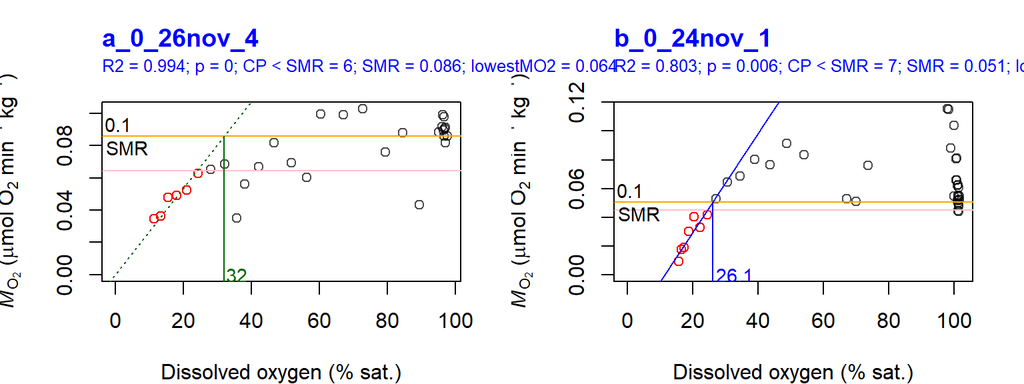

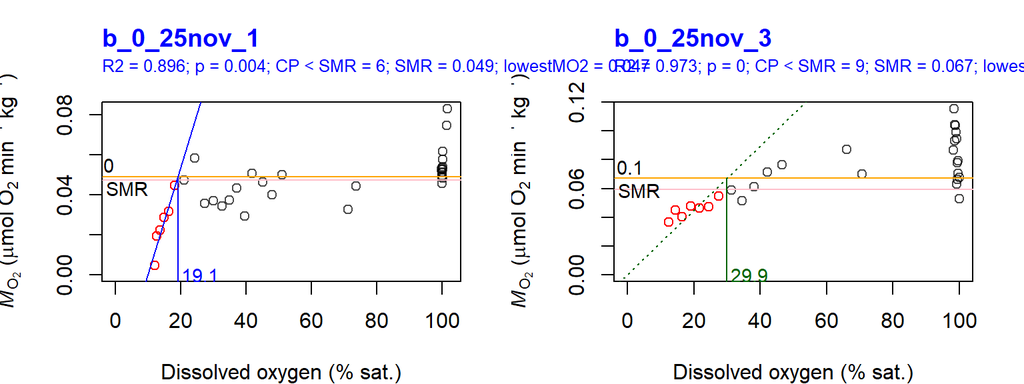

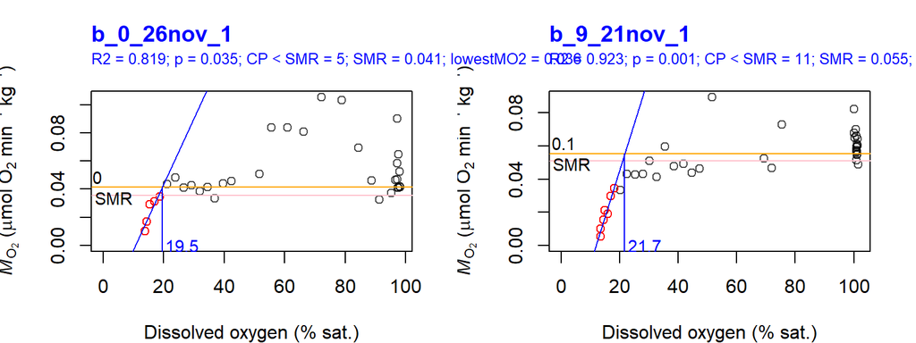

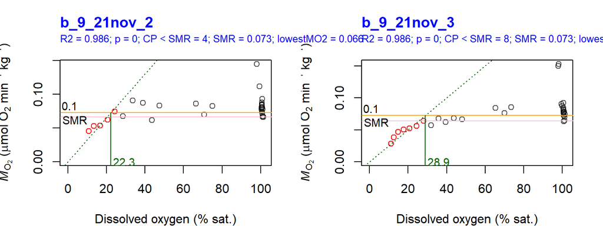

**Figure S8**: Representative examples of fish that were best modelled by a 2nd- or 3rd-order polynomial and meet the numerical inclusion criteria. The horizontal solid orange line shows the standard metabolic rate (SMR), the horizontal solid pink line shows thelowestMO2 (as defined by Claireaux and Chabot (2016)), the solid/dashed blue/green slope line shows the O2 regulation failure regression (based on the rule-based linear regression method of Claireaux and Chabot (2016); where the colour and line type indicate the type of regression fitted, through orgin or not), and the solid vertical blue/green line shows the O2crit estimate (intersection of O2 failure regression and SMR).

Pulling model method and lethal points

### Figure S9

Making a O2crit plot for each of the eight fish that past visual and numerical assessment on the same axis.

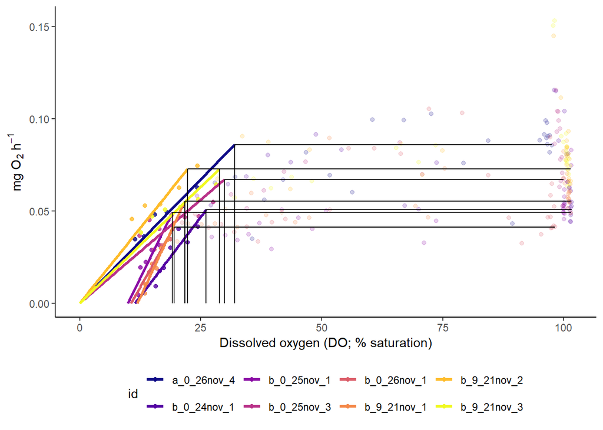

### Figure 2

Let’s make some example plots for each major types of O2-MO2 relationships (i.e. 0<sup>th</sup>-, 1<sup>st</sup>-, and 2<sup>nd</sup>/3<sup>rd</sup>- order polynomial).

First an example of a 0th-order polynomial fit (c_9_24nov_4).

Second an example of a 1st-order polynomial best fit (d_9_25nov_3).

Last an example of a fish best fit with a higher order polynomial (2nd-order).

Let’s combined them in one plot

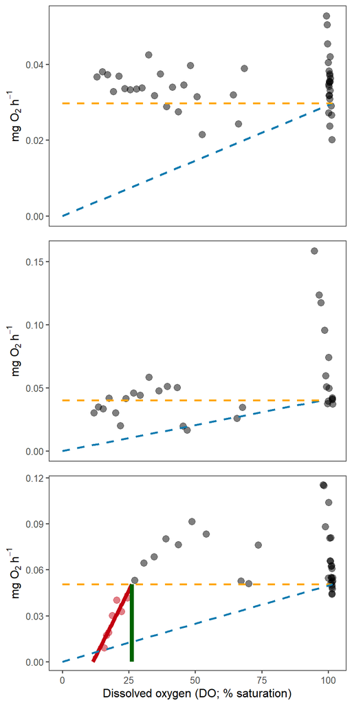

# Comapring to past data

First making a binned data frame to match Urbina, Glover, and Forster (2012) as closely as possible.

## Figure 3

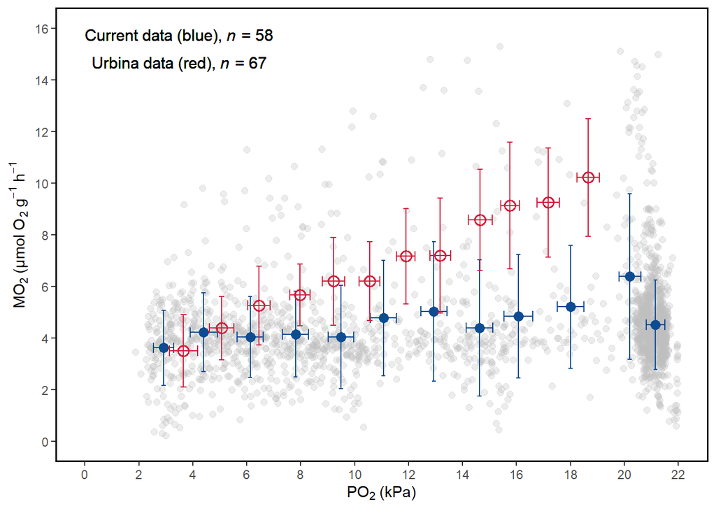

# 📚 References

<sup>[1]</sup> Claireaux, G. and Chabot, D. (2016) Responses by fishes to environmental hypoxia: integration through Fry’s concept of aerobic metabolic scope. Journal of Fish Biology https://doi.org/10.1111/jfb.12833

<sup>[2]</sup> Urbina MA, Glover CN, and Forster ME, (2012) A novel oxyconforming response in the freshwater fish *Galaxias maculatus*. Comparative Biochemistry and Physiology Part A: Molecular & Integrative Physiology. https://doi.org/10.1016/j.cbpa.2011.11.011

<sup>[3]</sup> Pick JL, Nakagawa S, and Noble DWA (2018) Reproducible, flexible and high-throughput data extraction from primary literature: The metaDigitise r package. https://doi.org/10.1111/2041-210X.13118

# 💻 Session information

[output not shown]